# DATA 606 Final Project

# Ten Year CHD prevalence

```r
table(fhs$TenYearCHD)
```

```
##
##    0    1
## 3596  644
```

Among the all participants, 3596 participants without TenYearCHD, 644 participants with TenYearCHD.

# Current Smoker prevalence (0:non_smoker;1:smoker)

```r
table(fhs$currentSmoker)
```

```
##
##    0    1
## 2145 2095
```

# Hypertension Prevalence (0:normal, 1:hypertension)

```r
table(fhs$prevalentHyp)
```

```
##
##    0    1
## 2923 1317
```

# Diabetes prevalence

```r
table(fhs$diabetes)
```

```
##
##    0    1
## 4131  109
```

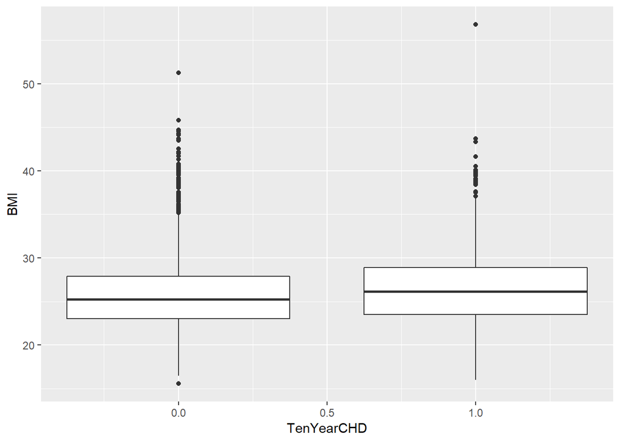

```r
ggplot(data = fhs, aes(x = TenYearCHD, y = BMI,group=TenYearCHD)) +
  geom_boxplot()
```

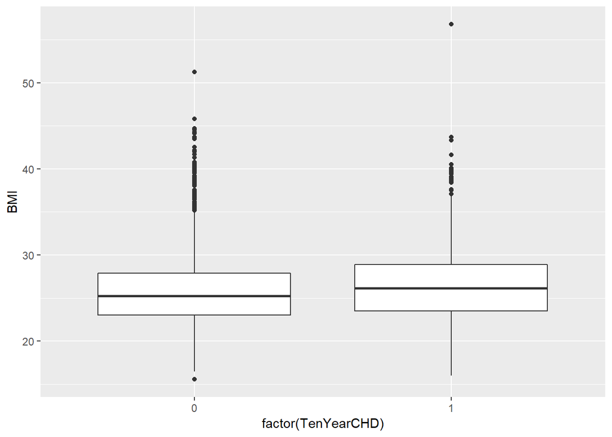

```r
ggplot(data = fhs, aes(x = factor(TenYearCHD), y = BMI)) +
  geom_boxplot()
```

#Explore Data

```r
glimpse(fhs)
```

```
## Observations: 4,240
## Variables: 16
## $ male            <int> 1, 0, 1, 0, 0, 0, 0, 0, 1, 1, 0, 0, 1, 0, 0, 0...
## $ age             <int> 39, 46, 48, 61, 46, 43, 63, 45, 52, 43, 50, 43...
## $ education       <int> 4, 2, 1, 3, 3, 2, 1, 2, 1, 1, 1, 2, 1, 3, 2, 2...
## $ currentSmoker   <int> 0, 0, 1, 1, 1, 0, 0, 1, 0, 1, 0, 0, 1, 0, 1, 1...
## $ cigsPerDay      <int> 0, 0, 20, 30, 23, 0, 0, 20, 0, 30, 0, 0, 15, 0...
## $ BPMeds          <int> 0, 0, 0, 0, 0, 0, 0, 0, 0, 0, 0, 0, 0, 1, 0, 0...
## $ prevalentStroke <int> 0, 0, 0, 0, 0, 0, 0, 0, 0, 0, 0, 0, 0, 0, 0, 0...
## $ prevalentHyp    <int> 0, 0, 0, 1, 0, 1, 0, 0, 1, 1, 0, 0, 1, 1, 0, 1...
## $ diabetes        <int> 0, 0, 0, 0, 0, 0, 0, 0, 0, 0, 0, 0, 0, 0, 0, 0...
## $ totChol         <int> 195, 250, 245, 225, 285, 228, 205, 313, 260, 2...
## $ sysBP           <dbl> 106.0, 121.0, 127.5, 150.0, 130.0, 180.0, 138....
## $ diaBP           <dbl> 70.0, 81.0, 80.0, 95.0, 84.0, 110.0, 71.0, 71....
## $ BMI             <dbl> 26.97, 28.73, 25.34, 28.58, 23.10, 30.30, 33.1...
## $ heartRate       <int> 80, 95, 75, 65, 85, 77, 60, 79, 76, 93, 75, 72...
## $ glucose         <int> 77, 76, 70, 103, 85, 99, 85, 78, 79, 88, 76, 6...
## $ TenYearCHD      <int> 0, 0, 0, 1, 0, 0, 1, 0, 0, 0, 0, 0, 0, 0, 0, 1...
```

# BMI related Ten Year CHD incidence

```r
mod0<-glm(TenYearCHD~BMI+age+diabetes+prevalentHyp+currentSmoker, data=fhs, family=binomial)
mod0
```

```
##
## Call:  glm(formula = TenYearCHD ~ BMI + age + diabetes + prevalentHyp +
##     currentSmoker, family = binomial, data = fhs)
##
## Coefficients:
##   (Intercept)            BMI            age       diabetes   prevalentHyp
##      -6.29940        0.01814        0.06908        0.82298        0.63088
## currentSmoker
##       0.52487
##
## Degrees of Freedom: 4220 Total (i.e. Null);  4215 Residual
##   (19 observations deleted due to missingness)
## Null Deviance:       3571
## Residual Deviance: 3268  AIC: 3280
```

```r
summary(mod0)
```

```
##
## Call:
## glm(formula = TenYearCHD ~ BMI + age + diabetes + prevalentHyp +
##     currentSmoker, family = binomial, data = fhs)
##
## Deviance Residuals:
##     Min       1Q   Median       3Q      Max
## -1.5114  -0.6039  -0.4434  -0.3308   2.5719
##
## Coefficients:
##                Estimate Std. Error z value Pr(>|z|)
## (Intercept)   -6.299401   0.429949 -14.652  < 2e-16 ***
## BMI            0.018144   0.011021   1.646 0.099716 .
## age            0.069083   0.005764  11.985  < 2e-16 ***
## diabetes       0.822977   0.217329   3.787 0.000153 ***
## prevalentHyp   0.630882   0.096994   6.504 7.80e-11 ***
## currentSmoker  0.524874   0.094503   5.554 2.79e-08 ***
## ---
## Signif. codes:  0 '***' 0.001 '**' 0.01 '*' 0.05 '.' 0.1 ' ' 1
##
## (Dispersion parameter for binomial family taken to be 1)
##
##     Null deviance: 3571.5  on 4220  degrees of freedom
## Residual deviance: 3267.9  on 4215  degrees of freedom
##   (19 observations deleted due to missingness)
## AIC: 3279.9
##
## Number of Fisher Scoring iterations: 5
```

# As continuous variable, BMI did not reach statistical signficance. So we tried to transform it into categorical data.

The following are the ranges to define different categories of BMI. Underweight: BMI is less than 18.5 Normal weight: BMI is 18.5 to 24.9 Overweight: BMI is 25 to 29.9 Obese: BMI is 30 or more We are going to study whether BMI >30 as obese is a risk factor of CHD Here, we create 2 categories, BMI<=30 non-obese, BMI>30 obese

```r
fhs$obesity<-ifelse(fhs$BMI>30, 1,0)
```

```r
glimpse(fhs)
```

```
## Observations: 4,240
## Variables: 17
## $ male            <int> 1, 0, 1, 0, 0, 0, 0, 0, 1, 1, 0, 0, 1, 0, 0, 0...
## $ age             <int> 39, 46, 48, 61, 46, 43, 63, 45, 52, 43, 50, 43...
## $ education       <int> 4, 2, 1, 3, 3, 2, 1, 2, 1, 1, 1, 2, 1, 3, 2, 2...
## $ currentSmoker   <int> 0, 0, 1, 1, 1, 0, 0, 1, 0, 1, 0, 0, 1, 0, 1, 1...
## $ cigsPerDay      <int> 0, 0, 20, 30, 23, 0, 0, 20, 0, 30, 0, 0, 15, 0...
## $ BPMeds          <int> 0, 0, 0, 0, 0, 0, 0, 0, 0, 0, 0, 0, 0, 1, 0, 0...
## $ prevalentStroke <int> 0, 0, 0, 0, 0, 0, 0, 0, 0, 0, 0, 0, 0, 0, 0, 0...
## $ prevalentHyp    <int> 0, 0, 0, 1, 0, 1, 0, 0, 1, 1, 0, 0, 1, 1, 0, 1...
## $ diabetes        <int> 0, 0, 0, 0, 0, 0, 0, 0, 0, 0, 0, 0, 0, 0, 0, 0...
## $ totChol         <int> 195, 250, 245, 225, 285, 228, 205, 313, 260, 2...
## $ sysBP           <dbl> 106.0, 121.0, 127.5, 150.0, 130.0, 180.0, 138....
## $ diaBP           <dbl> 70.0, 81.0, 80.0, 95.0, 84.0, 110.0, 71.0, 71....
## $ BMI             <dbl> 26.97, 28.73, 25.34, 28.58, 23.10, 30.30, 33.1...
## $ heartRate       <int> 80, 95, 75, 65, 85, 77, 60, 79, 76, 93, 75, 72...
## $ glucose         <int> 77, 76, 70, 103, 85, 99, 85, 78, 79, 88, 76, 6...
## $ TenYearCHD      <int> 0, 0, 0, 1, 0, 0, 1, 0, 0, 0, 0, 0, 0, 0, 0, 1...
## $ obesity         <dbl> 0, 0, 0, 0, 0, 1, 1, 0, 0, 0, 0, 0, 0, 1, 0, 0...
```

```r
mod2 <- glm( TenYearCHD ~ obesity + male+diabetes + prevalentHyp+currentSmoker, data = fhs,family=binomial)
mod2
```

```
##
## Call:  glm(formula = TenYearCHD ~ obesity + male + diabetes + prevalentHyp +
##     currentSmoker, family = binomial, data = fhs)
##
## Coefficients:
##   (Intercept)        obesity           male       diabetes   prevalentHyp
##      -2.46102        0.05307        0.49228        1.02231        0.96554
## currentSmoker
##       0.15445
##
## Degrees of Freedom: 4220 Total (i.e. Null);  4215 Residual
##   (19 observations deleted due to missingness)
## Null Deviance:       3571
## Residual Deviance: 3391  AIC: 3403
```

```r
summary(mod2)
```

```
##
## Call:
## glm(formula = TenYearCHD ~ obesity + male + diabetes + prevalentHyp +
##     currentSmoker, family = binomial, data = fhs)
##
## Deviance Residuals:
##     Min       1Q   Median       3Q      Max
## -1.2750  -0.5632  -0.4358  -0.4047   2.2552
##
## Coefficients:
##               Estimate Std. Error z value Pr(>|z|)
## (Intercept)   -2.46102    0.08886 -27.697  < 2e-16 ***
## obesity        0.05307    0.12621   0.421   0.6741
## male           0.49228    0.09039   5.446 5.15e-08 ***
## diabetes       1.02231    0.21330   4.793 1.64e-06 ***
## prevalentHyp   0.96554    0.09126  10.580  < 2e-16 ***
## currentSmoker  0.15445    0.09150   1.688   0.0914 .
## ---
## Signif. codes:  0 '***' 0.001 '**' 0.01 '*' 0.05 '.' 0.1 ' ' 1
##
## (Dispersion parameter for binomial family taken to be 1)
##
##     Null deviance: 3571.5  on 4220  degrees of freedom
## Residual deviance: 3391.4  on 4215  degrees of freedom
##   (19 observations deleted due to missingness)
## AIC: 3403.4
##
## Number of Fisher Scoring iterations: 4
```

```r
table(fhs$obesity)
```

```
##
##    0    1
## 3685  536
```

# Now, we focuse on the age above 50 yd group

```r
fhs2<- filter(fhs, age>50)
```

let us look at the new dataframe fhs

```r
glimpse(fhs2)
```

```
## Observations: 1,883
## Variables: 17
## $ male            <int> 0, 0, 1, 0, 0, 0, 0, 0, 0, 1, 1, 1, 1, 0, 1, 0...
## $ age             <int> 61, 63, 52, 52, 52, 60, 61, 60, 59, 61, 54, 56...
## $ education       <int> 3, 1, 1, 1, 3, 1, 3, 1, 1, NA, 1, NA, 1, 1, 2,...
## $ currentSmoker   <int> 1, 0, 0, 0, 1, 0, 0, 0, 0, 1, 1, 0, 0, 0, 0, 0...
## $ cigsPerDay      <int> 30, 0, 0, 0, 20, 0, 0, 0, 0, 5, 20, 0, 0, 0, 0...
## $ BPMeds          <int> 0, 0, 0, 0, 0, 0, 0, 0, 0, 0, 0, 0, 0, 1, 0, 1...
## $ prevalentStroke <int> 0, 0, 0, 0, 0, 0, 0, 0, 0, 0, 0, 0, 0, 0, 0, 0...
## $ prevalentHyp    <int> 1, 0, 1, 0, 0, 0, 1, 0, 1, 0, 1, 0, 1, 1, 0, 1...
## $ diabetes        <int> 0, 0, 0, 0, 0, 0, 0, 0, 0, 0, 0, 0, 1, 0, 0, 1...
## $ totChol         <int> 225, 205, 260, 234, 215, 260, 272, 247, 209, 1...
## $ sysBP           <dbl> 150.0, 138.0, 141.5, 148.0, 132.0, 110.0, 182....
## $ diaBP           <dbl> 95.0, 71.0, 89.0, 78.0, 82.0, 72.5, 121.0, 88....
## $ BMI             <dbl> 28.58, 33.11, 26.36, 34.17, 25.11, 26.59, 32.8...
## $ heartRate       <int> 65, 60, 76, 70, 71, 65, 85, 72, 90, 72, 96, 72...
## $ glucose         <int> 103, 85, 79, 113, 75, NA, 65, 74, 88, 75, 87, ...
## $ TenYearCHD      <int> 1, 1, 0, 0, 0, 0, 1, 0, 1, 1, 0, 0, 0, 1, 0, 1...
## $ obesity         <dbl> 0, 1, 0, 1, 0, 0, 1, 1, 0, 0, 0, 0, 1, 0, 0, 0...
```

```r
table(fhs2$obesity)
```

```
##
##    0    1
## 1597  276
```

```r
table(fhs2$TenYearCHD)
```

```
##
##    0    1
## 1452  431
```

```r
mod3 <- glm( TenYearCHD ~ obesity + male+diabetes + prevalentHyp+currentSmoker, data = fhs2, family=binomial)
mod3
```

```
##
## Call:  glm(formula = TenYearCHD ~ obesity + male + diabetes + prevalentHyp +
##     currentSmoker, family = binomial, data = fhs2)
##
## Coefficients:
##   (Intercept)        obesity           male       diabetes   prevalentHyp
##       -1.9847         0.1058         0.5089         0.7806         0.7520
## currentSmoker
##        0.2604
##
## Degrees of Freedom: 1872 Total (i.e. Null);  1867 Residual
##   (10 observations deleted due to missingness)
## Null Deviance:       2004
## Residual Deviance: 1925  AIC: 1937
```

```r
summary(mod3)
```

```
##
## Call:
## glm(formula = TenYearCHD ~ obesity + male + diabetes + prevalentHyp +
##     currentSmoker, family = binomial, data = fhs2)
##
## Deviance Residuals:
##     Min       1Q   Median       3Q      Max
## -1.3615  -0.7207  -0.6417  -0.5075   2.0560
##
## Coefficients:
##               Estimate Std. Error z value Pr(>|z|)
## (Intercept)    -1.9847     0.1148 -17.287  < 2e-16 ***
## obesity         0.1058     0.1583   0.668  0.50389
## male            0.5089     0.1183   4.302 1.69e-05 ***
## diabetes        0.7806     0.2484   3.142  0.00168 **
## prevalentHyp    0.7520     0.1166   6.451 1.11e-10 ***
## currentSmoker   0.2604     0.1196   2.177  0.02945 *
## ---
## Signif. codes:  0 '***' 0.001 '**' 0.01 '*' 0.05 '.' 0.1 ' ' 1
##
## (Dispersion parameter for binomial family taken to be 1)
##
##     Null deviance: 2003.6  on 1872  degrees of freedom
## Residual deviance: 1925.1  on 1867  degrees of freedom
##   (10 observations deleted due to missingness)
## AIC: 1937.1
##
## Number of Fisher Scoring iterations: 4
```

# To stuy the male gender

```r
fhs3<-filter(fhs2, male==1)
```

```r
glimpse(fhs3)
```

```
## Observations: 780
## Variables: 17
## $ male            <int> 1, 1, 1, 1, 1, 1, 1, 1, 1, 1, 1, 1, 1, 1, 1, 1...
## $ age             <int> 52, 61, 54, 56, 52, 54, 51, 56, 53, 57, 60, 53...
## $ education       <int> 1, NA, 1, NA, 1, 2, 4, 4, 1, 1, 1, 1, 4, 3, 1,...
## $ currentSmoker   <int> 0, 1, 1, 0, 0, 0, 0, 1, 1, 0, 1, 1, 1, 0, 0, 0...
## $ cigsPerDay      <int> 0, 5, 20, 0, 0, 0, 0, 20, 20, 0, 20, 20, 30, 0...
## $ BPMeds          <int> 0, 0, 0, 0, 0, 0, 0, 0, 0, 0, 0, 0, 0, 0, 0, 0...
## $ prevalentStroke <int> 0, 0, 0, 0, 0, 0, 0, 0, 0, 0, 0, 0, 0, 0, 0, 0...
## $ prevalentHyp    <int> 1, 0, 1, 0, 1, 0, 0, 0, 0, 0, 1, 0, 0, 1, 1, 0...
## $ diabetes        <int> 0, 0, 0, 0, 1, 0, 0, 0, 0, 0, 0, 0, 0, 0, 0, 0...
## $ totChol         <int> 260, 175, 214, 257, 178, 195, 216, 270, 220, 2...
## $ sysBP           <dbl> 141.5, 134.0, 147.0, 153.5, 160.0, 132.0, 112....
## $ diaBP           <dbl> 89.0, 82.5, 74.0, 102.0, 98.0, 83.5, 66.0, 79....
## $ BMI             <dbl> 26.36, 18.59, 24.71, 28.09, 40.11, 26.21, 23.4...
## $ heartRate       <int> 76, 72, 96, 72, 75, 75, 90, 95, 78, 75, 90, 60...
## $ glucose         <int> 79, 75, 87, 75, 225, 100, 95, 93, 73, 64, 83, ...
## $ TenYearCHD      <int> 0, 1, 0, 0, 0, 0, 0, 0, 0, 1, 0, 0, 1, 0, 1, 0...
## $ obesity         <dbl> 0, 0, 0, 0, 1, 0, 0, 0, 0, 0, 0, 0, 0, 0, 0, 0...
```

```r
mod4 <- lm( TenYearCHD ~ obesity + diabetes + prevalentHyp+currentSmoker, data = fhs3, family=binomial)
mod4
```

```
##
## Call:
## lm(formula = TenYearCHD ~ obesity + diabetes + prevalentHyp +
##     currentSmoker, data = fhs3, family = binomial)
##
## Coefficients:
##   (Intercept)        obesity       diabetes   prevalentHyp  currentSmoker
##       0.15968        0.07385        0.26057        0.11473        0.10064
```

```r
summary(mod4)
```

```
##
## Call:
## lm(formula = TenYearCHD ~ obesity + diabetes + prevalentHyp +
##     currentSmoker, data = fhs3, family = binomial)
##
## Residuals:
##     Min      1Q  Median      3Q     Max
## -0.7095 -0.2744 -0.2335  0.5511  0.8403
##
## Coefficients:
##               Estimate Std. Error t value Pr(>|t|)
## (Intercept)    0.15968    0.02677   5.964 3.75e-09 ***
## obesity        0.07385    0.05364   1.377 0.168947
## diabetes       0.26057    0.07666   3.399 0.000711 ***
## prevalentHyp   0.11473    0.03278   3.499 0.000493 ***
## currentSmoker  0.10064    0.03182   3.162 0.001627 **
## ---
## Signif. codes:  0 '***' 0.001 '**' 0.01 '*' 0.05 '.' 0.1 ' ' 1
##
## Residual standard error: 0.4379 on 772 degrees of freedom
##   (3 observations deleted due to missingness)
## Multiple R-squared:  0.04509,    Adjusted R-squared:  0.04014
## F-statistic: 9.114 on 4 and 772 DF,  p-value: 3.388e-07
```

# study gender=female

```r
fhs4 <- filter(fhs2, male==0)
```

```r
glimpse(fhs4)
```

```
## Observations: 1,103
## Variables: 17
## $ male            <int> 0, 0, 0, 0, 0, 0, 0, 0, 0, 0, 0, 0, 0, 0, 0, 0...
## $ age             <int> 61, 63, 52, 52, 60, 61, 60, 59, 52, 53, 65, 63...
## $ education       <int> 3, 1, 1, 3, 1, 3, 1, 1, 1, 3, 1, 2, 1, 1, 1, 1...
## $ currentSmoker   <int> 1, 0, 0, 1, 0, 0, 0, 0, 0, 0, 0, 1, 1, 0, 1, 0...
## $ cigsPerDay      <int> 30, 0, 0, 20, 0, 0, 0, 0, 0, 0, 0, 40, 3, 0, 9...
## $ BPMeds          <int> 0, 0, 0, 0, 0, 0, 0, 0, 1, 1, 0, 0, 0, 0, 0, 0...
## $ prevalentStroke <int> 0, 0, 0, 0, 0, 0, 0, 0, 0, 0, 0, 0, 0, 0, 0, 0...
## $ prevalentHyp    <int> 1, 0, 0, 0, 0, 1, 0, 1, 1, 1, 1, 0, 1, 0, 0, 1...
## $ diabetes        <int> 0, 0, 0, 0, 0, 0, 0, 0, 0, 1, 0, 0, 0, 0, 1, 0...
## $ totChol         <int> 225, 205, 234, 215, 260, 272, 247, 209, NA, 31...
## $ sysBP           <dbl> 150.0, 138.0, 148.0, 132.0, 110.0, 182.0, 130....
## $ diaBP           <dbl> 95.0, 71.0, 78.0, 82.0, 72.5, 121.0, 88.0, 85....
## $ BMI             <dbl> 28.58, 33.11, 34.17, 25.11, 26.59, 32.80, 30.3...
## $ heartRate       <int> 65, 60, 70, 71, 65, 85, 72, 90, 70, 76, 90, 95...
## $ glucose         <int> 103, 85, 113, 75, NA, 65, 74, 88, NA, 215, 87,...
## $ TenYearCHD      <int> 1, 1, 0, 0, 0, 1, 0, 1, 1, 1, 0, 1, 1, 0, 0, 0...
## $ obesity         <dbl> 0, 1, 1, 0, 0, 1, 1, 0, 0, 0, 1, 0, 0, 0, 0, 0...
```

```r
mod5 <- lm( TenYearCHD ~ obesity + diabetes + prevalentHyp + currentSmoker, data = fhs4,family=binomial)
mod5
```

```
##
## Call:
## lm(formula = TenYearCHD ~ obesity + diabetes + prevalentHyp +
##     currentSmoker, data = fhs4, family = binomial)
##
## Coefficients:
##   (Intercept)        obesity       diabetes   prevalentHyp  currentSmoker
##      0.122729      -0.007899       0.076696       0.136878       0.001147
```

```r
summary(mod5)
```

```
##
## Call:
## lm(formula = TenYearCHD ~ obesity + diabetes + prevalentHyp +
##     currentSmoker, data = fhs4, family = binomial)
##
## Residuals:
##     Min      1Q  Median      3Q     Max
## -0.3375 -0.2596 -0.1227 -0.1227  0.8852
##
## Coefficients:
##                Estimate Std. Error t value Pr(>|t|)
## (Intercept)    0.122729   0.018800   6.528 1.02e-10 ***
## obesity       -0.007899   0.031249  -0.253    0.800
## diabetes       0.076696   0.062879   1.220    0.223
## prevalentHyp   0.136878   0.024132   5.672 1.81e-08 ***
## currentSmoker  0.001147   0.026432   0.043    0.965
## ---
## Signif. codes:  0 '***' 0.001 '**' 0.01 '*' 0.05 '.' 0.1 ' ' 1
##
## Residual standard error: 0.388 on 1091 degrees of freedom
##   (7 observations deleted due to missingness)
## Multiple R-squared:  0.03228,    Adjusted R-squared:  0.02873
## F-statistic: 9.097 on 4 and 1091 DF,  p-value: 3.14e-07
```